# Hayman Fire Recovery

Quinn Miller

February 04, 2022

## Question 1

What is the correlation between NDVI and NDMI?

The normalized difference vegetation index (NDVI) and normalized difference moisture index (NDMI) have a strong positive linear relationship. NDVI is a measure of how much of the ground is covered by healthy green vegetation– low values indicate bare soil, and high values suggest dense green leaves. NDMI is used to measure vegetation water content, where low values indicate vegetative water stress (Gao B.C. 1996). The graph below shows a clear distinction between the burned and unburned sites; the burned sites have much lower NDMI and NDVI.

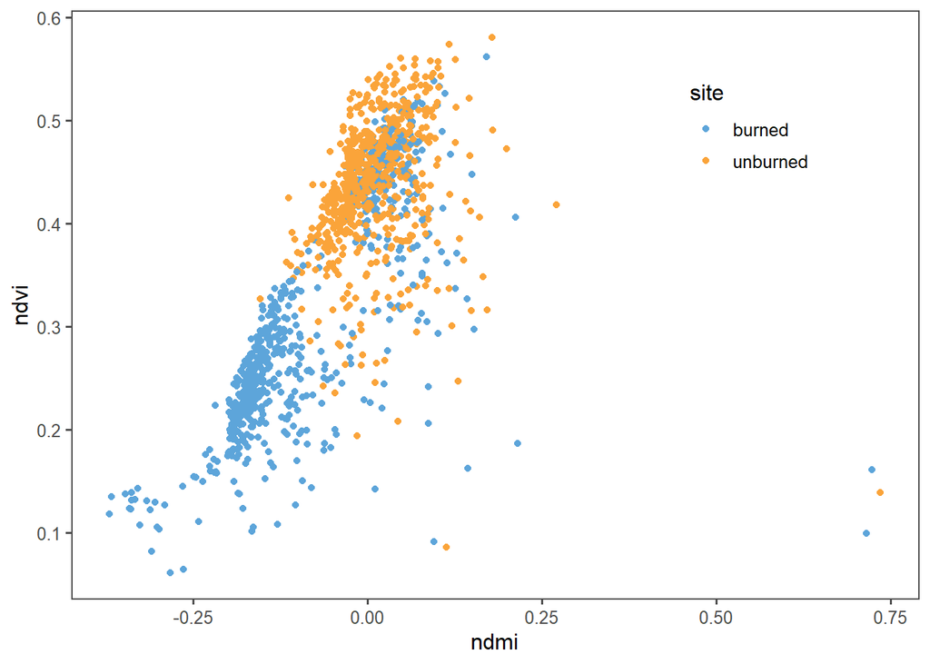

## Question 2

What is the correlation between average NDSI (normalized snow index) for January - April and average NDVI for June-August? In other words, does the previous year’s snow cover influence vegetation growth for the following summer?

There is a very weak positive correlation between average winter NDSI and average summer NDVI. It does not appear as though the previous year’s snow cover has much of an influence on the following summer’s vegetation.

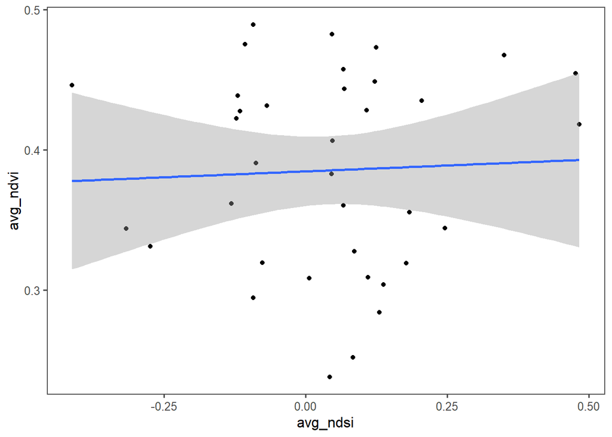

## Question 3

How is the snow effect from question 2 different between pre- and post-burn and burned and unburned?

The graph below shows how the Hayman Fire influenced the relationship between mean NDSI and mean NDVI in the sample area. The unburned plot shows little distinction between the pre- and post-burn conditions, whereas the burned plot shows a marked difference between the two. In general, the relationship described in the answer to question two is the same once the burn is taken into account; post-burn NDVI values are just noticeably lower.

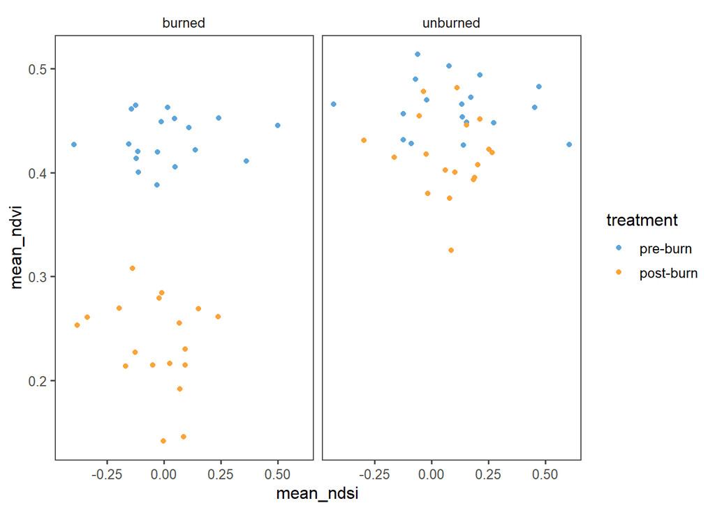

## Question 4

What month is the greenest month on average?

Averaging across the burned and unburned sites, and using NDVI to determine green vegetation, it appears that August is the greenest month on average for the time period 1984-2019.

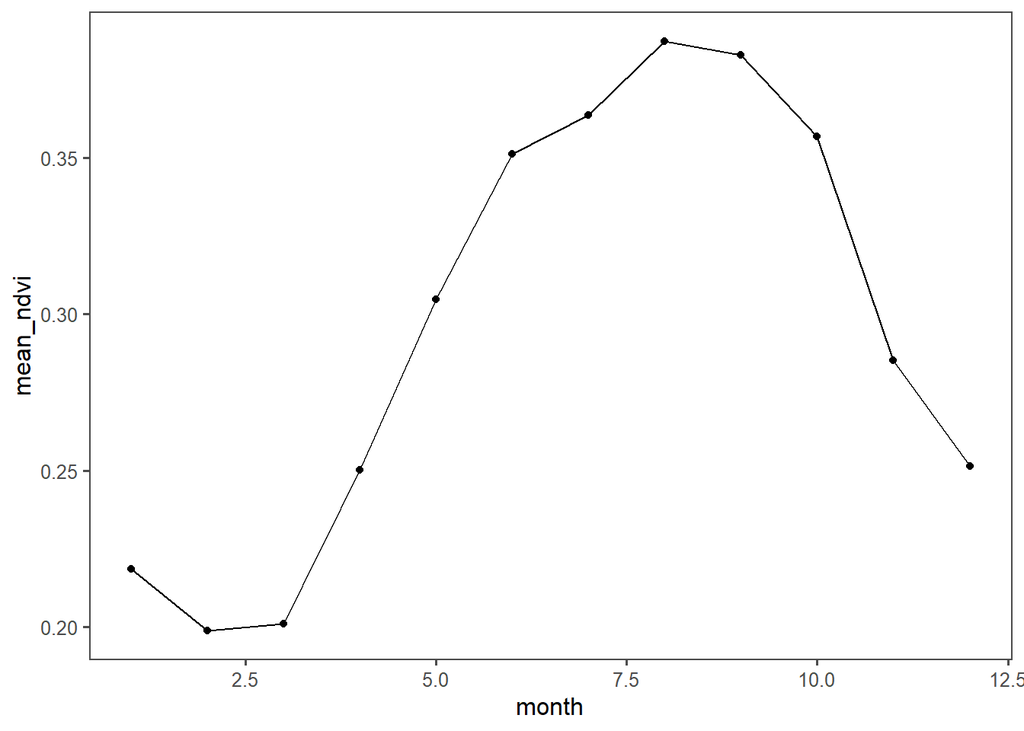

## Question 5

What month is the snowiest on average?

Averaging across the burned and unburned sites, and using NDSI to determine snow cover, it appears that January is the snowiest month on average for the time period 1984-2019.

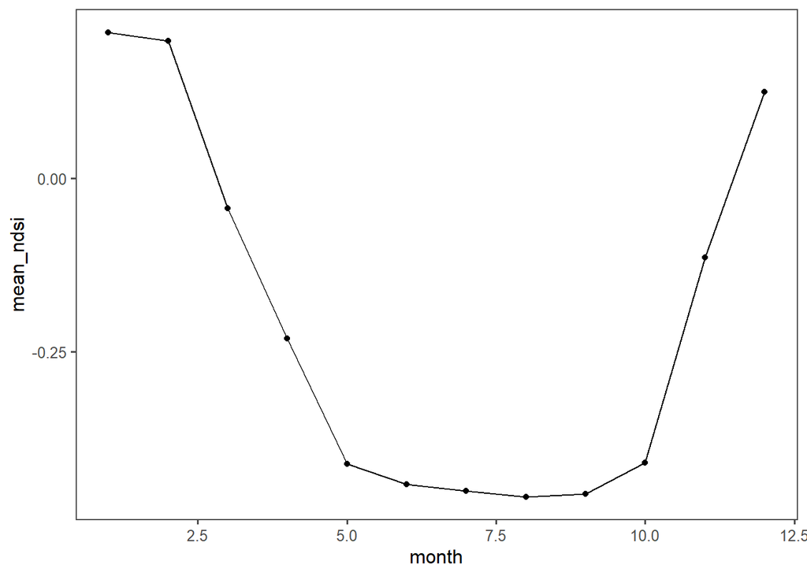

## Appendix

```r
library(tidyverse)
library(tidyr)
library(ggthemes)
library(lubridate)

# Now that we have learned how to munge (manipulate) data
# and plot it, we will work on using these skills in new ways

knitr::opts_knit$set(root.dir='..')
####-----Reading in Data and Stacking it ----- ####
#Reading in files
files <- list.files('data',full.names=T)


#Read in individual data files
ndmi <- read_csv(files[1]) %>%
  rename(burned=2,unburned=3) %>%
  mutate(data='ndmi')


ndsi <- read_csv(files[2]) %>%
  rename(burned=2,unburned=3) %>%
  mutate(data='ndsi')

ndvi <- read_csv(files[3])%>%
  rename(burned=2,unburned=3) %>%
  mutate(data='ndvi')

# Stack as a tidy dataset
full_long <- rbind(ndvi,ndmi,ndsi) %>%
  pivot_longer(c(burned,unburned), names_to = "site", values_to = "value") %>%
  filter(!is.na(value))

#Q1
full_wide <- pivot_wider(data=full_long,names_from='data',values_from='value') %>%
  filter_if(is.numeric,all_vars(!is.na(.))) %>%
  mutate(month = month(DateTime),
         year = year(DateTime))

summer_only <- filter(full_wide,month %in% c(6,7,8,9))

ggplot(summer_only,aes(x=ndmi,y=ndvi,color=site)) +
  geom_point() +
  theme_few() +
  scale_color_few() +
  theme(legend.position=c(0.8,0.8))
#Q2
ndvi_summer <- filter(full_wide, month %in% c(6,7,8))%>%
  group_by(year) %>%
  mutate(avg_ndvi = mean(ndvi)) %>%
  select(year, avg_ndvi) %>%
  distinct()

ndsi_winter <- filter(full_wide, month %in% c(1,2,3,4))%>%
  group_by(year) %>%
  mutate(avg_ndsi = mean(ndsi)) %>%
  select(year, avg_ndsi) %>%
  distinct()

summer_winter <- full_join(ndvi_summer, ndsi_winter, by = "year")

ggplot(data=summer_winter,aes(x=avg_ndsi,y=avg_ndvi)) +
  geom_point() +
  theme_few() +
  geom_smooth(method = "lm", formula = y~x)


#Q3
ndsi_prepost <- full_wide %>%
  mutate(treatment = cut(year,breaks=c(1983,2001, 2019),
                         labels=c('pre-burn','post-burn'))) %>%
  filter(month %in% c(1,2,3,4)) %>%
  group_by(year,site,treatment) %>%
  summarize(mean_ndsi = mean(ndsi))

ndvi_prepost <- full_wide %>%
  mutate(treatment = cut(year,breaks=c(1983,2001, 2019),
                         labels=c('pre-burn','post-burn'))) %>%
  filter(month %in% c(6,7,8)) %>%
  group_by(year,site,treatment) %>%
  summarize(mean_ndvi = mean(ndvi))

summer_winter_pre_post <- inner_join(ndvi_prepost, ndsi_prepost, by = c("year", "site", "treatment"))


ggplot(summer_winter_pre_post,aes(x=mean_ndsi,y=mean_ndvi, color = treatment)) +
  geom_point() +
  theme_few() +
  scale_color_few()+
  facet_wrap(~site)

#Q4
green <- full_wide %>%
  group_by(month) %>%
  summarize(mean_ndvi = mean(ndvi))

ggplot(green,aes(x=month,y=mean_ndvi)) +
  geom_point()+
  geom_line() +
  theme_few()

#Q5
snow <- full_wide %>%
  group_by(month) %>%
  summarize(mean_ndsi = mean(ndsi))

ggplot(snow,aes(x=month,y=mean_ndsi)) +
  geom_point()+
  geom_line() +
  theme_few()
```